# COVID-19 Analysis in the US

2024-11-20

## Introduction

The COVID-19 pandemic has had a profound impact on healthcare, economies, and daily life worldwide. The purpose of this analysis is to explore the COVID-19 case and death trends in the United States using the dataset provided by Johns Hopkins University. Specifically, we aim to answer the following question:

**What are the trends in confirmed COVID-19 cases and deaths over time in the United States, and how do they differ across states?**

## Data Source

The data is sourced from the Johns Hopkins University GitHub repository, which hosts daily updates on COVID-19 statistics. We will specifically use the following datasets:

- `data/time_series_covid19_deaths_US.csv`: Contains the number of deaths from COVID-19 in the United States.
- `data/time_series_covid19_confirmed_US.csv`: Contains the number of confirmed cases of COVID-19 in the United States.

## Data Import and Tidying

```r
# Tidying the deaths dataset
deaths_data_tidy <- deaths_data %>%
  gather(key = "date", value = "deaths", -c(UID, iso2, iso3, code3, FIPS, Admin2, Province_State, Country_Region, Lat, Long_, Combined_Key, Population)) %>%
  mutate(date = gsub("X", "", date),         # Remove the leading "X" from the date columns
         date = mdy(date))                   # Convert date from "m.d.yy" to Date format

# View the structure of the tidied deaths data
str(deaths_data_tidy)
```

```
## 'data.frame':    3819906 obs. of  14 variables:
##  $ UID           : int  84001001 84001003 84001005 84001007 84001009 84001011 84001013 84001015 84001017 84001019 ...
##  $ iso2          : chr  "US" "US" "US" "US" ...
##  $ iso3          : chr  "USA" "USA" "USA" "USA" ...
##  $ code3         : int  840 840 840 840 840 840 840 840 840 840 ...
##  $ FIPS          : num  1001 1003 1005 1007 1009 ...
##  $ Admin2        : chr  "Autauga" "Baldwin" "Barbour" "Bibb" ...
##  $ Province_State: chr  "Alabama" "Alabama" "Alabama" "Alabama" ...
##  $ Country_Region: chr  "US" "US" "US" "US" ...
##  $ Lat           : num  32.5 30.7 31.9 33 34 ...
##  $ Long_         : num  -86.6 -87.7 -85.4 -87.1 -86.6 ...
##  $ Combined_Key  : chr  "Autauga, Alabama, US" "Baldwin, Alabama, US" "Barbour, Alabama, US" "Bibb, Alabama, US" ...
##  $ Population    : int  55869 223234 24686 22394 57826 10101 19448 113605 33254 26196 ...
##  $ date          : Date, format: "2020-01-22" "2020-01-22" ...
##  $ deaths        : int  0 0 0 0 0 0 0 0 0 0 ...
```

```r
head(deaths_data_tidy)
```

```
##        UID iso2 iso3 code3 FIPS  Admin2 Province_State Country_Region      Lat
## 1 84001001   US  USA   840 1001 Autauga        Alabama             US 32.53953
## 2 84001003   US  USA   840 1003 Baldwin        Alabama             US 30.72775
## 3 84001005   US  USA   840 1005 Barbour        Alabama             US 31.86826
## 4 84001007   US  USA   840 1007    Bibb        Alabama             US 32.99642
## 5 84001009   US  USA   840 1009  Blount        Alabama             US 33.98211
## 6 84001011   US  USA   840 1011 Bullock        Alabama             US 32.10031
##       Long_         Combined_Key Population       date deaths
## 1 -86.64408 Autauga, Alabama, US      55869 2020-01-22      0
## 2 -87.72207 Baldwin, Alabama, US     223234 2020-01-22      0
## 3 -85.38713 Barbour, Alabama, US      24686 2020-01-22      0
## 4 -87.12511    Bibb, Alabama, US      22394 2020-01-22      0
## 5 -86.56791  Blount, Alabama, US      57826 2020-01-22      0
## 6 -85.71266 Bullock, Alabama, US      10101 2020-01-22      0
```

```r
# Tidying the confirmed cases dataset
confirmed_data_tidy <- confirmed_data %>%
  gather(key = "date", value = "confirmed", -c(UID, iso2, iso3, code3, FIPS, Admin2, Province_State, Country_Region, Lat, Long_, Combined_Key)) %>%
  mutate(date = gsub("X", "", date),         # Remove the leading "X" from the date columns
         date = mdy(date))                   # Convert date from "m.d.yy" to Date format

# View the structure of the tidied confirmed data
str(confirmed_data_tidy)
```

```
## 'data.frame':    3819906 obs. of  13 variables:
##  $ UID           : int  84001001 84001003 84001005 84001007 84001009 84001011 84001013 84001015 84001017 84001019 ...
##  $ iso2          : chr  "US" "US" "US" "US" ...
##  $ iso3          : chr  "USA" "USA" "USA" "USA" ...
##  $ code3         : int  840 840 840 840 840 840 840 840 840 840 ...
##  $ FIPS          : num  1001 1003 1005 1007 1009 ...
##  $ Admin2        : chr  "Autauga" "Baldwin" "Barbour" "Bibb" ...
##  $ Province_State: chr  "Alabama" "Alabama" "Alabama" "Alabama" ...
##  $ Country_Region: chr  "US" "US" "US" "US" ...
##  $ Lat           : num  32.5 30.7 31.9 33 34 ...
##  $ Long_         : num  -86.6 -87.7 -85.4 -87.1 -86.6 ...
##  $ Combined_Key  : chr  "Autauga, Alabama, US" "Baldwin, Alabama, US" "Barbour, Alabama, US" "Bibb, Alabama, US" ...
##  $ date          : Date, format: "2020-01-22" "2020-01-22" ...
##  $ confirmed     : int  0 0 0 0 0 0 0 0 0 0 ...
```

```r
head(confirmed_data_tidy)
```

```
##        UID iso2 iso3 code3 FIPS  Admin2 Province_State Country_Region      Lat
## 1 84001001   US  USA   840 1001 Autauga        Alabama             US 32.53953
## 2 84001003   US  USA   840 1003 Baldwin        Alabama             US 30.72775
## 3 84001005   US  USA   840 1005 Barbour        Alabama             US 31.86826
## 4 84001007   US  USA   840 1007    Bibb        Alabama             US 32.99642
## 5 84001009   US  USA   840 1009  Blount        Alabama             US 33.98211
## 6 84001011   US  USA   840 1011 Bullock        Alabama             US 32.10031
##       Long_         Combined_Key       date confirmed
## 1 -86.64408 Autauga, Alabama, US 2020-01-22         0
## 2 -87.72207 Baldwin, Alabama, US 2020-01-22         0
## 3 -85.38713 Barbour, Alabama, US 2020-01-22         0
## 4 -87.12511    Bibb, Alabama, US 2020-01-22         0
## 5 -86.56791  Blount, Alabama, US 2020-01-22         0
## 6 -85.71266 Bullock, Alabama, US 2020-01-22         0
```

### Discussion of Initial Processing

We observe that the original data is structured as a list of time-series of data points per locality. In order perform the desired analysis, we need to pivot the time-series columns to get a list of data points.

```r
# Aggregate by state and date
deaths_statewise <- deaths_data_tidy %>%
  group_by(Province_State, date) %>%
  summarise(total_deaths = sum(deaths, na.rm = TRUE))
deaths_statewise = data.frame(deaths_statewise)
head(deaths_statewise)
```

```
##   Province_State       date total_deaths
## 1        Alabama 2020-01-22            0
## 2        Alabama 2020-01-23            0
## 3        Alabama 2020-01-24            0
## 4        Alabama 2020-01-25            0
## 5        Alabama 2020-01-26            0
## 6        Alabama 2020-01-27            0
```

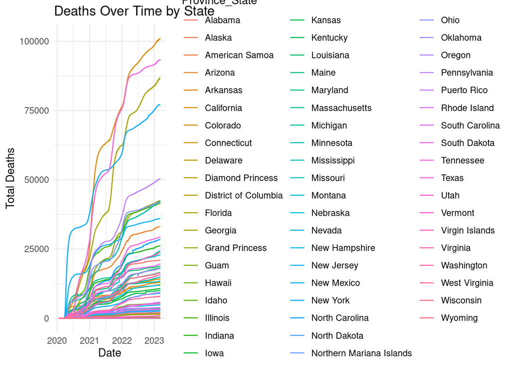

```r
# Plotting confirmed cases over time for each state
ggplot(deaths_statewise, aes(x = as.Date(date), y = total_deaths, color = Province_State)) +
  geom_line() +
  labs(title = "Deaths Over Time by State",
       x = "Date",
       y = "Total Deaths") +
  theme_minimal() +
  theme(legend.position = "right")  # Position the legend on the right
```

### Discussion of Death Counts

We plot the death counts over time by state. We see a similarly-shaped curve per state. The shape of the curve may be influenced by the lockdown measures implemented during the time period.

```r
# Aggregate by state and date
confirmed_statewise <- confirmed_data_tidy %>%
  group_by(Province_State, date) %>%
  summarise(total_confirmed = sum(confirmed, na.rm = TRUE))
confirmed_statewise = data.frame(confirmed_statewise)
head(confirmed_statewise)
```

```
##   Province_State       date total_confirmed
## 1        Alabama 2020-01-22               0
## 2        Alabama 2020-01-23               0
## 3        Alabama 2020-01-24               0
## 4        Alabama 2020-01-25               0
## 5        Alabama 2020-01-26               0
## 6        Alabama 2020-01-27               0
```

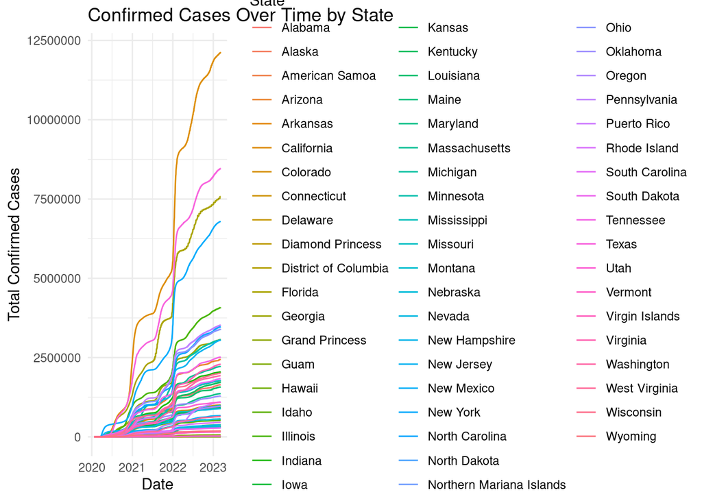

```r
# Plotting confirmed cases over time for each state on a single plot with a legend
ggplot(confirmed_statewise, aes(x = as.Date(date), y = total_confirmed, color = Province_State)) +
  geom_line() +  # Line plot
  labs(title = "Confirmed Cases Over Time by State",
       x = "Date",
       y = "Total Confirmed Cases",
       color = "State") +  # Adding a label for the legend
  theme_minimal() +
  theme(legend.position = "right")  # Position the legend on the right
```

### Discussion of Confirmed Cases

We plot the cases counts over time by state. We see a similarly-shaped curve per state. We observe for both functions that they are non-decreasing over time. We assume that these are cumulative totals reported at a given time for this data. We observe the scale of deaths is up to 100,000 whereas the scale of cases is 12,500,000.

## Data Visualization

Perform required pre-processing for visualizations.

```r
merged_data <- deaths_statewise %>%
  inner_join(confirmed_statewise, by = c("Province_State", "date"))

merged_data$date <- as.Date(merged_data$date)

merged_data_clean <- merged_data %>%
  filter(!is.na(date) & !is.na(total_confirmed) & !is.na(total_deaths) &
         !is.infinite(total_confirmed) & !is.infinite(total_deaths))

# Check again the clean data
summary(merged_data_clean)
```

```
##  Province_State          date             total_deaths    total_confirmed
##  Length:66294       Min.   :2020-01-22   Min.   :     0   Min.   :       0
##  Class :character   1st Qu.:2020-11-02   1st Qu.:   555   1st Qu.:   31115
##  Mode  :character   Median :2021-08-15   Median :  3849   Median :  293146
##                     Mean   :2021-08-15   Mean   : 10768   Mean   :  811738
##                     3rd Qu.:2022-05-28   3rd Qu.: 13695   3rd Qu.:  953450
##                     Max.   :2023-03-09   Max.   :101159   Max.   :12129699
```

### Visualization 1: Time Series of Confirmed Cases and Deaths

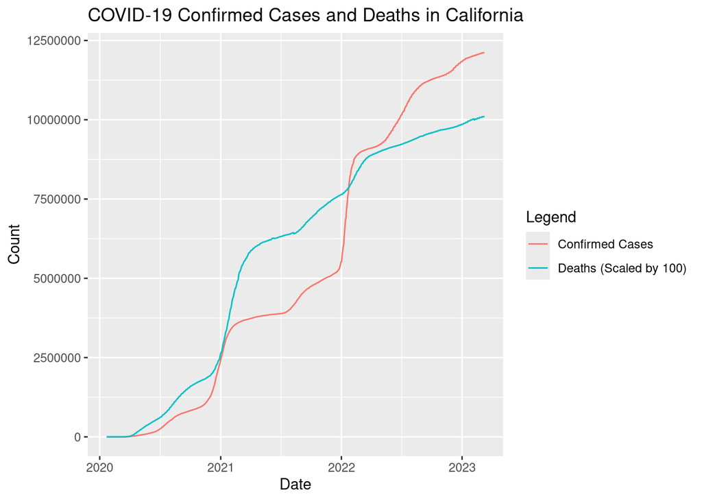

```r
# Plotting confirmed cases and deaths for California
ggplot(filter(merged_data_clean, Province_State == "California"), aes(x = date)) +
  geom_line(aes(y = total_confirmed, color = "Confirmed Cases")) +
  geom_line(aes(y = 100 * total_deaths, color = "Deaths (Scaled by 100)")) +
  labs(title = "COVID-19 Confirmed Cases and Deaths in California",
       x = "Date",
       y = "Count",
       color = "Legend")
```

### Discussion of Confirmed Cases in California

We observe the cases and deaths for California. We see similar shape of both curves but have to scale by factor of 100.

### Visualization 2: Confirmed Cases by State (Latest Date)

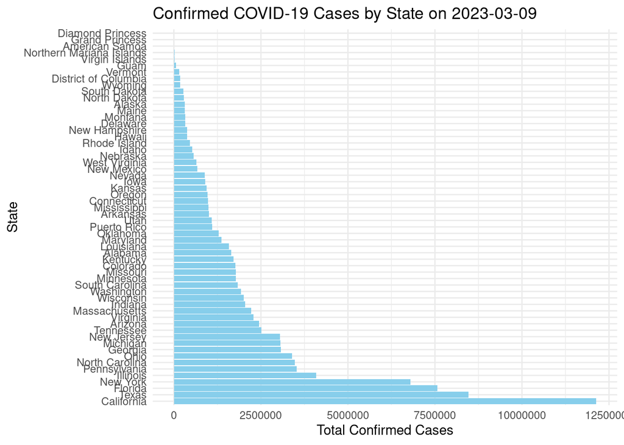

```r
# Plotting confirmed cases for all states on the latest date
latest_date <- max(confirmed_statewise$date)
latest_confirmed <- confirmed_statewise %>%
  filter(date == latest_date)

ggplot(latest_confirmed, aes(x = reorder(Province_State, -total_confirmed), y = total_confirmed)) +
  geom_col(fill = "skyblue") +
  coord_flip() +
  labs(title = paste("Confirmed COVID-19 Cases by State on", latest_date),
       x = "State",
       y = "Total Confirmed Cases") +
  theme_minimal()
```

### Discussion of Bar Chart of Cases by State.

We plot cases vs. state and see that densely populated states like New York, Florida and California have significantly high number of cases.

## Model: Regression Analysis of Confirmed Cases Over Time

We will model the number of confirmed cases over time in California to understand the trend better.

```r
# Fit a linear model
model <- lm(total_confirmed ~ date, data = filter(merged_data, Province_State == "California"))

# Summarizing the model
summary(model)
```

```
##
## Call:
## lm(formula = total_confirmed ~ date, data = filter(merged_data,
##     Province_State == "California"))
##
## Residuals:
##      Min       1Q   Median       3Q      Max
## -1774594  -640976   101179   652929  1805996
##
## Coefficients:
##               Estimate Std. Error t value Pr(>|t|)
## (Intercept) -2.324e+08  1.414e+06  -164.4   <2e-16 ***
## date         1.261e+04  7.497e+01   168.2   <2e-16 ***
## ---
## Signif. codes:  0 '***' 0.001 '**' 0.01 '*' 0.05 '.' 0.1 ' ' 1
##
## Residual standard error: 836300 on 1141 degrees of freedom
## Multiple R-squared:  0.9612, Adjusted R-squared:  0.9612
## F-statistic: 2.829e+04 on 1 and 1141 DF,  p-value: < 2.2e-16
```

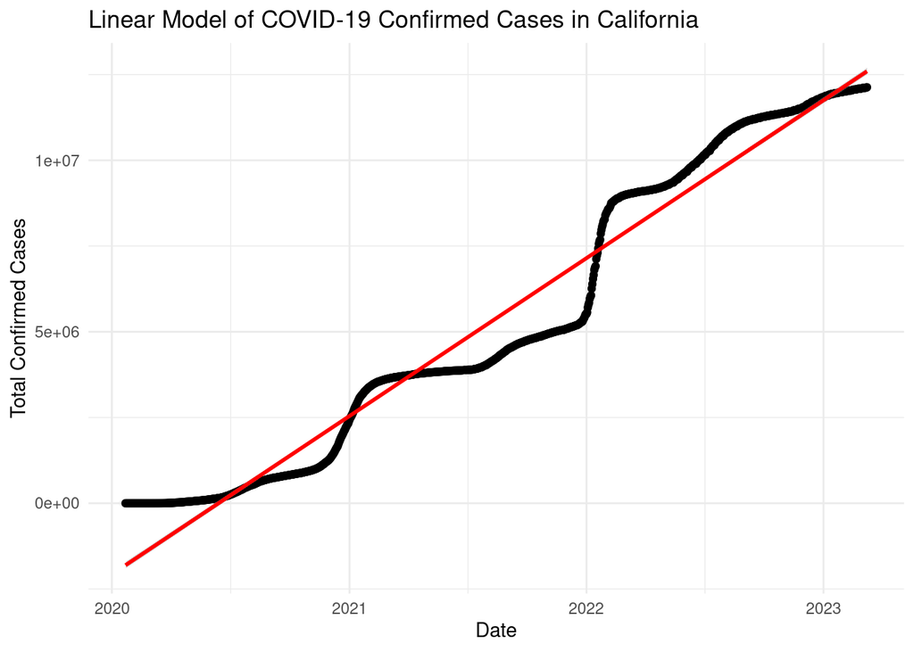

```r
# Plotting the trend line
ggplot(filter(merged_data, Province_State == "California"), aes(x = date, y = total_confirmed)) +
  geom_point() +
  geom_smooth(method = "lm", color = "red") +
  labs(title = "Linear Model of COVID-19 Confirmed Cases in California",
       x = "Date",
       y = "Total Confirmed Cases") +
  theme_minimal()
```

### Discussion of Model

We see that modeling confirmed cases linearly over date achieved R squared of 0.96 which is fairly good. However, information about lockdown measures could help explain the deviation from the linear trend.

## Discussion of Sources of Bias

The COVID-19 data is subject to several biases:

1. **Reporting Bias**: Different states may have varying criteria for testing and reporting cases, leading to inconsistencies in reported numbers.
2. **Data Completeness**: The dataset may be incomplete for earlier dates as testing was not widespread or uniformly applied.
3. **Population Size**: States with larger populations will inevitably show higher case numbers, which should be accounted for when comparing states.
4. **Temporal Bias**: The timing of interventions (e.g., lockdowns) greatly influences case counts and could provide skewed results if not properly analyzed.